# 4.0. Normal Distribution

The Normal distribution is an important and commonly used continuous distribution in Data Science because a good number of random variables occurring in practice can be approximated to it. You will encounter it at many places especially in topics of Statistical Inference. It is one of the assumptions of many data science algorithms too.

The most commonly seen and therefore well-known distribution of continuous values is the **bell curve**. It is known as the normal distribution, because it the distribution that a lot of data falls into. It is also known as the **Gaussian distribution**, more formally, named for Carl Friedrich Gauss. As such, you will see references to data being normally distributed or Gaussian, which are interchangeable, both referring to the same thing: that the data looks like the Normal distribution. Some examples of observations that have a Normal distribution include:

- People's heights.
- IQ scores.

A normal distribution has a bell-shaped density curve described by its mean $\mu$ and standard deviation $\sigma$. The density curve is symmetrical, centered about its mean, with its spread determined by its standard deviation showing that data near the mean are more frequent in occurrence than data far from the mean. The probability distribution function of a normal density curve with mean μ and standard deviation σ at a given point $x$ is given by:

$$ \large f(x) = {\frac {1}{\sigma \sqrt {2 \pi}}} \huge {e^ {- {\frac {(x -\mu)^2} {2 \sigma^2}}}} \normalsize {\text {for ${-\infty} \le x \le \infty$}}$$

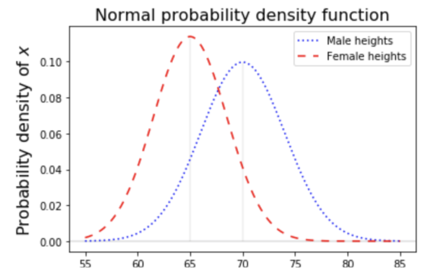

You can also generate a normally distributed random variable using `scipy.stats` module's `norm.rvs()` method. The `loc` argument corresponds to the mean of the distribution, `scale` corresponds to standard deviation and size to the number of random variates. If you want to maintain reproducibility, include a random_state argument assigned to a number.

```python
#parameters of Normal Distribution
mu = 100
sd =  3
size = 10000

from scipy.stats import norm

# generate random numbers from N(100,3)
data_normal = norm.rvs(size = size,loc = mu,scale = sd)
```

You can visualize the distribution just like you did with the uniform distribution, using seaborn's distplot functions. The meaning of the arguments remains the same as in the last case.

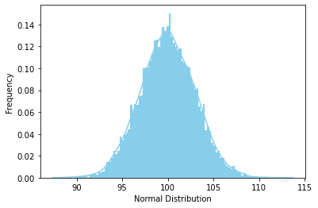

```python
import matplotlib.pyplot as plt
import seaborn as sns

ax = sns.distplot(data_normal,
                  bins=100,
                  kde=True,
                  color='skyblue',
                  hist_kws={"linewidth": 15,'alpha':1})
ax.set(xlabel='Normal Distribution', ylabel='Frequency')
plt.show()
```

If X is normally distributed with mean $\mu$ and variance $\sigma^2$, we write $X \thicksim N(\mu, \sigma^2)$. If the mean is 100 and the variance is 9, we write $X \thicksim N(100,3^2)$. Note how the variance is written. By writing $9$ as $3^2$, we explicitly show that the standard deviation is $3$.

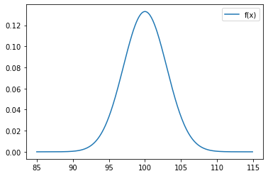

```python
# generate and plot Normal distribution
from numpy import arange
from matplotlib import pyplot
from scipy.stats import norm

# x-axis for the plot
x = arange(85,115,0.1)

# y-axis as the pdf of Normal Distribution

mean = 100
sd = 3

f_x = norm.pdf(x,100,3)

# plot data
pyplot.plot(x, f_x,label = 'f(x)')
pyplot.legend()
pyplot.show()
```

The mean $\mu$ and Standard Deviation $\sigma$ gives Normal Distribution its shape. The codes below demonstrated some Normal Distribution curves for example:

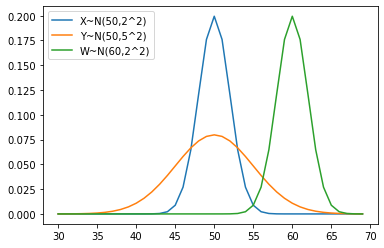

```python
# generate and plot gaussians with different variance
from numpy import arange
from matplotlib import pyplot as plt
from scipy.stats import norm


# x-axis for the plot
x_axis = arange(30, 70)

# Nomal Distribution with different means and s.d.
X = norm.pdf(x_axis, 50, 2)
Y = norm.pdf(x_axis, 50, 5)
W = norm.pdf(x_axis,60,2)

plt.plot(x_axis,X,label = 'X~N(50,2^2)')
plt.plot(x_axis,Y,label = 'Y~N(50,5^2)')
plt.plot(x_axis,W,label = 'W~N(60,2^2)')

plt.legend()
plt.show()
```

The above figure shows three normal distributions: $X \thicksim N(50, 2^2)$; $Y \thicksim N(50, 5^2)$; $W \thicksim N(60, 2^2)$. Note their shapes and positions.

# 4.1. Standard Normal Distribution

We define the Standard Normal random variable $Z$ as the Normal random variable with mean $\mu = 0$ and standard deviation $\sigma = 1$. i.e.,

$$\boxed {Z \thicksim N(0, 1 )}$$

Running the following example generates a plot of an idealized Gaussian distribution. The x-axis are the observations and the y-axis is the probability of each observation. In this case, observations around 0.0 are the most common and observations around -3.0 and 3.0 are rare or unlikely. Technically, this is called a **Standard Normal Distribution**.

Let's look at a Standard Normal Distribution.

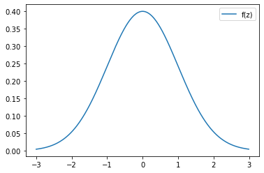

```python
# generate and plot an idealized Normal
from numpy import arange
from matplotlib import pyplot
from scipy.stats import norm

# x-axis for the plot
x_axis = arange(-3,3,0.01)

# y-axis as the gaussian
y_axis = norm.pdf(x_axis,0,1)

# plot data
pyplot.plot(x_axis, y_axis,label = 'f(z)')
pyplot.legend()
pyplot.show()
```

# 4.2. The Transformation of Normal Random Variables

We want to transform $X$, where $X \thicksim N(\mu,\sigma^2)$, into the standard normal random variable $Z \thicksim N(0, 1)$.

The importance of the standard normal distribution derives from the fact that any normal random variable may be transformed to the standard normal random variable.

Look at figure below. Here we have a normal random variable $X$ with mean $\mu = 50$ and standard deviation $\sigma=10$. We want to transform this random variable to a normal random variable with $\mu = 0$ and $\sigma=1$. How can we do this?

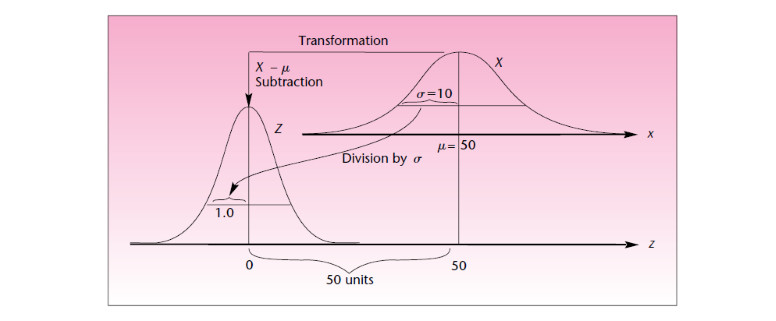

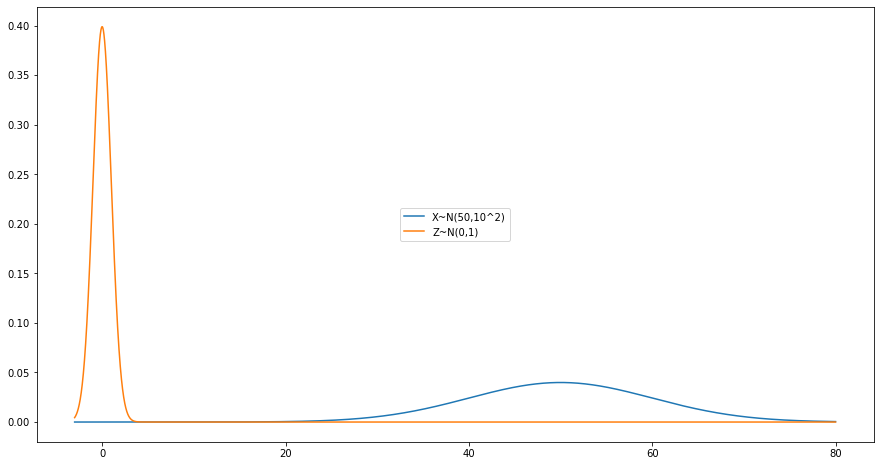

```python
# generate and plot gaussians with different variance
from numpy import arange
from matplotlib import pyplot
from scipy.stats import norm
# x-axis for the plot
x_axis = arange(-3, 80,0.01)

pyplot.figure(figsize=(15,8))

# plot low variance
pyplot.plot(x_axis, norm.pdf(x_axis, 50, 10),label = 'X~N(50,10^2)')
# plot high variance
pyplot.plot(x_axis, norm.pdf(x_axis, 0, 1),label = 'Z~N(0,1)')

pyplot.legend(loc = 'center')
pyplot.show()
```

We move the distribution from its center of 50 to a center of 0. This is done by subtracting 50 from all the values of X. Thus, we shift the distribution 50 units back so that its new center is 0. The second thing we need to do is to make the width of the distribution, its standard deviation, equal to 1. This is done by squeezing the width down from 10 to 1. **Because the total probability under the curve must remain 1.00, the distribution must grow upward to maintain the same area.** The same is shown in the figure.

Mathematically, squeezing the curve to make the width 1 is equivalent to dividing the random variable by its standard deviation. The area under the curve adjusts so that the total remains the same. All probabilities (areas under the curve) adjust accordingly. The mathematical transformation from $X$ to $Z$ is thus achieved by first subtracting $\mu$ from X and then dividing the result by $\sigma$.

Thus, the **Transformation of $X$ to $Z$** can be done using:

$$ \boxed {Z = \frac {X - \mu}{\sigma} }$$

We also have an opposite, or inverse, transformation, which takes us from the standard normal random variable $Z$ to the random variable $X$ with mean $\mu$ and standard deviation $\sigma$.

**Inverse Transformation of $Z$ to $X$**

$$ \boxed {X = \mu + Z\sigma }$$

# 4.3. Area Property (68-95-99.7 Rule) of Normal Distribution

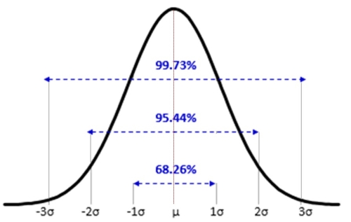

Almost 68% of the data falls within a distance of one standard deviation from the mean on either side and 95% within two standard deviations.

# 4.4. Normality Test

A large fraction of the field of statistics is concerned with data that assumes that it was drawn from a Normal distribution. Various Statistical methods (such as Linear Regression) assume that the data has a known and specific distribution, often a Normal distribution. If methods used assume a Normal distribution, and your data was drawn from a different distribution, the findings may be misleading or plain wrong. There are a range of techniques that you can use to check if your data sample deviates from a Normal distribution, called normality tests.

There are three main areas where you may need to make this evaluation of a data sample in a machine learning project; they are:

- Input data to the model in the case of fitting models.
- Model evaluation results in the case of model selection.
- Residual errors from model predictions in the case of regression.

**Visual Normality Checks**

These checks are qualitative, so less accurate than the statistical methods (such as Shapiro-Wilk Test & Anderson-Darling). Nevertheless, they are fast and useful to to check whether data is Normal.

A simple and commonly used plot to quickly check the distribution of a sample of data is the **Histogram**.If the histogram plot of sample data shows the familiar bell shape,then it has a Normal distribution.

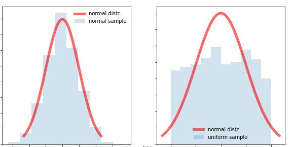

A histogram can be created using the `hist()` Matplotlib function. By default, the number of bins is automatically estimated from the data sample. Before we start looking at normality tests, let's first develop a test dataset that we can use throughout this tutorial. We will generate a small sample of random numbers drawn from a Normal distribution.

```python
# generate gaussian data
from numpy.random import seed
from numpy.random import randn
from numpy import mean
from numpy import std

# seed the random number generator
seed(1)

# generate univariate observations
data = 5 * randn(100) + 50

# summarize
print('mean=%.3f stdv=%.3f' % (mean(data), std(data)))
```

```
mean=50.303 stdv=4.426
```

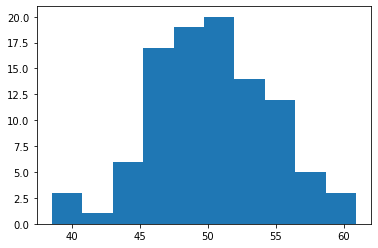

```python
# histogram plot
import matplotlib.pyplot as plt

plt.hist(data)
plt.show()
```

It is a bit strongly stated fact that no single dataset will be a perfectly normally distributed sample. But **in applied statistics the question is not whether the data is perfectly normal, but normal enough for the assumptions to hold**. There is also some middle ground where we can assume that the data is Normal-enough (also known as **Pseudo-Normal** or **Normal-like** ) to use statistical methods or that we can use data preparation techniques to transform the data to be sufficiently Normal to use the statistical methods.

**The problem with Histograms**

Histogram is one graphical way to say that the data comes from a normal distribution, but the histogram can be deceptive since changing the number of bins alter the shape of the distribution and this may lead to some confusion. We need a better way to identify if the data comes from a normal distribution. This is where quantile-quantile plots come in.

An alternative to using a histogram is to use a quantile-quantile plot or **Q-Q plot**.

## Q-Q plot

The Q-Q plot, or quantile-quantile plot, is a graphical tool to help us assess if a set of data plausibly came from some theoretical distribution such as a Normal Distribution. It’s again just a visual check, not an air-tight proof, so it is somewhat subjective. But it allows us to see at-a-glance if our assumption is plausible, and if not, how the assumption is violated and what data points contribute to the violation.

A Q-Q plot is a scatterplot created by plotting two sets of quantiles against one another. If both sets of quantiles came from the same distribution, we should see the points forming a line that’s roughly straight. Here’s an example of a Normal Q-Q plot when both sets of quantiles truly come from Normal distributions.

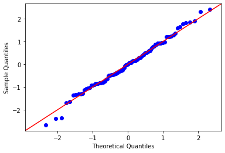

```python
import statsmodels.api as sm
import matplotlib.pyplot as plt

sm.qqplot(data, fit = True, line="45")
plt.show()
```

### How does it work?

We plot the theoretical quantiles or basically known as the standard normal variate (a normal distribution with mean=0 and standard deviation=1) on the x-axis and the ordered values for the random variable which we want to find whether it is Normally distributed or not, on the y-axis. Which gives a very beautiful and a smooth straight line like structure from each point plotted on the graph.

Now we have to focus on the ends of the straight line. If the points at the ends of the curve formed from the points are not falling on a straight line but indeed are scattered significantly from the positions, then we cannot conclude a relationship between the x and y axes which clearly signifies that our ordered values which we wanted to calculate are not Normally distributed.

If all the points plotted on the graph perfectly lies on a straight line then we can clearly say that this distribution is Normally distribution because it is evenly aligned with the standard normal variate which is the simple concept of Q-Q plot.

To help you identify different types of distributions from a quantile-quantile plot, we give examples of histograms and quantile-quantile plots:

**Normally distributed data:** Below is an example of data that are drawn from a normal distribution. The normal distribution is symmetric, so it has no skew (the mean is equal to the median).

On a Q-Q plot normally distributed data appears as roughly a straight line (although the ends of the Q-Q plot often start to deviate from the straight line).

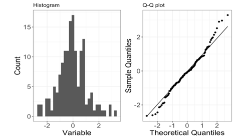

**Right-skewed data**

Below is an example of data that are drawn from a distribution that is right-skewed (in this case it is the exponential distribution). Right-skew is also known as positive skew. On a Q-Q plot right-skewed data appears curved.

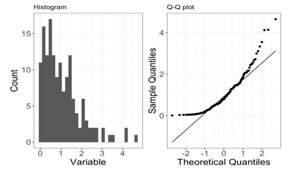

**Left-skewed data**

Below is an example of data (150 observations) that are drawn from a distribution that is left-skewed (in this case it is a negative exponential distribution). Left-skew is also known as negative skew. On a Q-Q plot left-skewed data appears curved (the opposite of right-skewed data).

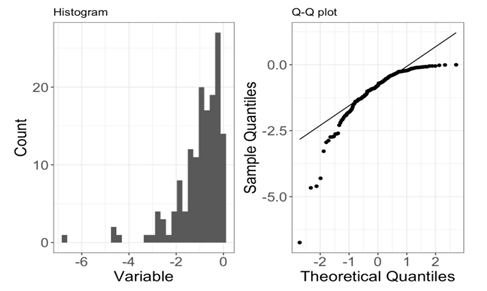

# 4.5. Making Data Normal

It is possible that your data does not look Normal or fails a normality test, but can be transformed to make it fit a Normal distribution. There is no silver bullet for this process; some experimentation and judgment may be required.

There are many reasons why the dataset may not be technically Normal.

### Sample Size

One common reason that a data sample is non-Normal is because the size of the data sample is too small. If this is the case, perhaps you can collect more data. Thanks to the *law of large numbers*, the more data that you collect, the more likely your data will be able to used to describe the underlying population distribution.

To make this concrete, below is an example of a plot of a small sample of 10 observations drawn from a Normal distribution with a mean of 100 and a standard deviation of 50.

```
10
```

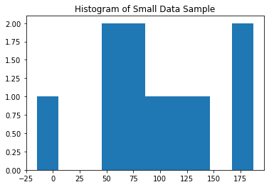

```python
# histogram plot of a small sample

from numpy.random import seed
from numpy.random import randn
import matplotlib.pyplot as plt

# seed the random number generator
seed(1)

# generate a univariate data sample
data = 50 * randn(10) + 100

print(len(data))

# histogram
plt.hist(data)
plt.title('Histogram of Small Data Sample')
plt.show()
```

Running the example creates a histogram plot of the data showing no clear Gaussian distribution, not even Normal-like. Increasing the size of the sample from 10 to 100 can help to better expose the Normal shape of the data distribution.

```
100
```

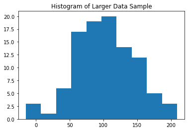

```python
# histogram plot of a small sample
from numpy.random import seed
from numpy.random import randn
import matplotlib.pyplot as plt

# seed the random number generator
seed(1)

# generate a univariate data sample
data = 50 * randn(100) + 100

print(len(data))

# histogram
plt.hist(data)
plt.title('Histogram of Larger Data Sample')
plt.show()
```

### Outliers

A data sample may have a Normal distribution, but may be distorted for a number of reasons. A common reason is the presence of extreme values at the edge of the distribution. Extreme values could be present for a number of reasons, such as:

- Measurement error.
- Missing data.
- Data corruption.
- Rare events.

In such cases, the extreme values could be identified and removed in order to make the distribution more Normal. These extreme values are often called **outliers**. This may require domain expertise or consultation with a domain expert in order to both design the criteria for identifying outliers and then removing them from the data sample.

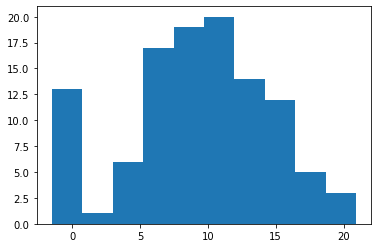

```python
# histogram plot of data with outliers
from numpy.random import seed
from numpy.random import randn
from numpy import zeros
from numpy import append
from matplotlib import pyplot

# seed the random number generator
seed(1)

# generate a univariate data sample
data = 5 * randn(100) + 10

# add extreme values
data = append(data, zeros(10))

# histogram
pyplot.hist(data)
pyplot.show()
```

### Power Transforms

The distribution of the data may be normal, but the data may require a transform in order to help expose it.

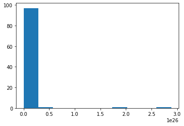

```python
# log-normal distribution
from numpy.random import seed
from numpy.random import randn
from numpy import exp
from matplotlib import pyplot

# seed the random number generator
seed(1)

# generate two sets of univariate observations
data = exp (5 * randn(100) + 50)

# histogram
pyplot.hist(data)
pyplot.show()
```

In some cases, this can be corrected by transforming the data via calculating the square root of the observations.

Alternately, the distribution may be exponential, but may look normal if the observations are transformed by taking the natural logarithm of the values. Data with this distribution is called log-normal.

Taking the square root and the logarithm of the observation in order to make the distribution normal belongs to a class of transforms called power transforms. The **Box-Cox method** is a data transform method that is able to perform a range of power transforms, including the log and the square root. It can be thought of as a power tool to automatically transform and iron out power-based change in your data sample.

The SciPy function `boxcox()` implements the Box-Cox method. It takes an argument, called lambda, that controls the type of transform to perform.

Below are some common values for lambda:

- `lambda = -1` is a reciprocal transform.
- `lambda = -0.5` is a reciprocal square root transform.
- `lambda = 0.0` is a log transform.
- `lambda = 0.5` is a square root transform.
- `lambda = 1.0` is no transform.

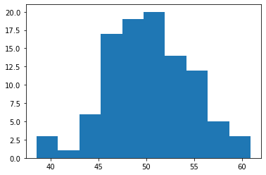

```python
from scipy.stats import boxcox

# power transform
data = boxcox(data, 0
             )  #applying log transformation on data


# histogram
pyplot.hist(data)
pyplot.show()
```

# Extra Reading:

It is also possible to draw Normal Random Variables using the basic NumPy package. Following code snippet is one such illustration:

```
mu = 50 #mean of the distribution
sd = 10 #std. deviation of the distribution
size = 200 # sample size

from numpy import random
data_normal = random.normal(loc = mu, scale = sd, size = size)
```